# UNHCR Quarto Document

Create UNHCR branded HTML article

Author

Cédric Vidonne

Published

3 July 2023

## Quarto HTML document

Create stunning [UNHCR branded](https://www.unhcr.org/brand) HTML document mixing text, images, tables, plots, code and more, directly with this template.

As with the other UNHCR Quarto extensions, the underlying document syntax is `markdown`. You can find all the information on authoring documents with Quarto [here](https://quarto.org/docs/authoring/markdown-basics.html). You can find more specific information on [figures](https://quarto.org/docs/authoring/figures.html) and [tables](https://quarto.org/docs/authoring/tables.html).

### UNHCR HTML Template

The `unhcr-html` Quarto template comes with predefined styles and components but Quarto is extremely flexible and, depending on your needs, you can modify many aspects directly from the document `YAML` or by simply using `CSS` classes. We recommend you stick with the default options but look at the reference below to know more about what you can do with Quarto.

Refer to the Quarto guide for [HTML document](https://quarto.org/docs/output-formats/html-basics.html) or the complete [HTML format reference](https://quarto.org/docs/reference/formats/html.html) for more information.

#### Title box

Some attributes of the `YAML` will be used to populate the top banner, such as the `title`, `date`, `author` and more. By default the banner is part of the other content flow and uses the default white background. You can turn it to a UNHCR blue banner, separated from the rest, by adding `title-block-banner: true` in the `YAML`. For example:

```yaml
---
title: UNHCR Quarto Document
subtitle: Create UNHCR branded HTML article
date: today
author: Cédric Vidonne
format: unhcr-html
title-block-banner: true
---
```

Note that only the `title`, `subtitle` and `description` attribute will be added to the blue banner. The other parameters will keep their default styling. Find more information on the title blocks [here](https://quarto.org/docs/authoring/title-blocks.html#title-banners).

#### Table of content

By default, the table of content is **visible**. Simply add `toc: false` to the `YAML` to hide the toc. You can find more information on toc and its settings [here](https://quarto.org/docs/output-formats/html-basics.html#table-of-contents).

#### Footer

A footer including the UNHCR logo will be added at the bottom of the page automatically.

## Typography

In this section, we will show the basic usage of the template on how to make UNHCR branded HTML document but as Quarto is using [Bootstrap](https://getbootstrap.com/), almost all the functionalities of the framework are available to you. Please, refer to the offical [Bootstrap documentation](https://getbootstrap.com/docs/5.3/getting-started/introduction/) to see what you can do with some simple `CSS` classes.

You can add classes, attributes, and other identifiers to regions of content using Divs and Spans.

For example, here we add the `{.bg-primary}` class to a region of content using a div (`:::`):

```markdown
::: {.bg-primary}
This content will be styled with a UNHCR blue background
:::
```

You can achieve the same at the `span` level with inline styling. For example:

```markdown
This is normal text but [this text will be in UNHCR blue]{.text-primary}.
```

Check the Quarto documention on [Divs and Spans](https://quarto.org/docs/authoring/markdown-basics.html#divs-and-spans) for more information and examples.

### Headings

Simply use the `markdown` notation for headings `#` to create your content structure. For example:

```markdown
# Heading 1
## Heading 2
### Heading 3
#### Heading 4
##### Heading 5
###### Heading 6
```

Heading 1

Heading 2

Heading 3

#### Heading 4

##### Heading 5

###### Heading 6

### Inline text

Simply use the `markdown` built-in notation to format your content. For example:

```markdown
*This line will render as italicized text.*

**This line will render as bold text.**

***This line will render as bold and italic text.***

`This line will render as inline code.`

~~This line will be strikethrough.~~

This line will include a [link to UNHCR webpage](https://www.unhcr.org/)
```

*This line will render as italicized text.*

**This line will render as bold text.**

*This line will render as bold and italic text.*

`This line will render as inline code.`

This line will be strikethrough.

This line will include a [link to UNHCR webpage](https://www.unhcr.org/)

Not all the formatting can be achieved with `markdown` only, but Quarto understands `HTML` so extra styling can be perfomed by directly entering `HTML` code in your Quarto document. For example:

```markdown
<u>This line of text will render as underlined.</u>
```

This line of text will render as underlined.

The template also includes some `CSS` classes to help with formating. For example:

```markdown
:::{.lead}
This is a lead paragraph. It stands out from regular paragraphs.
:::

You can use the mark class to [highlight]{.mark} text.

[This line of text is meant to be treated as fine print.]{.small}
```

This is a lead paragraph. It stands out from regular paragraphs.

You can use the mark class to highlight text.

This line of text is meant to be treated as fine print.

Useful for UNHCR document you can also create **footnotes** and **abbreviations** with the following code:

```markdown
This is a footnote^[Text of the footnote]

<abbr title="The United Nations High Commissioner for Refugees">UNHCR</abbr>
```

This is a footnote[^1]

UNHCR

For more examples and options, check the [Bootstrap documentation on typography](https://getbootstrap.com/docs/5.3/content/typography/).

### Lists

The template comes with stylized lists, simply create them using `markdown` notation. For examples:

```markdown
* unordered list
    + sub-item 1
    + sub-item 2
        - sub-sub-item 1

1. ordered list
2. item 2
    i) sub-item 1
         A.  sub-sub-item 1
```

- unordered list
  - sub-item 1
  - sub-item 2
    - sub-sub-item 1
1. ordered list
2. item 2
   1. sub-item 1
      1. sub-sub-item 1

### Blockquote

Blockquote can be achieved with `markdown` using the `>` notation. To include a quote author, add a blank line with the `>` character and a line with the `>` character for the author itself. The `{.blockquote-author}` class **must** be added to the text for the credential. For example:

```markdown
> "A simple blockquote"

> "A blockquote with source"
>
> [From an important person]{.blockquote-author}
```

> “A simple blockquote”

> “A blockquote with source”

> From an important person

Note that the **"** character has to be added manually, directly to the quote.

### Callout blocks

Callout blocks can be helpful to attract reader’s attention. Please review the [Quarto article on callouts](https://quarto.org/docs/authoring/callouts.html) for more information. Below an example of a `note` callout.

```markdown
::: {.callout-note}
Note that there are five types of callouts, including: `note`, `tip`, `warning`, `caution`, and `important`.

And their style can be changed further with the `appearance` attribute.
:::
```

**Note**

Note that there are five types of callouts, including: `note`, `tip`, `warning`, `caution`, and `important`.

And their style can be changed further with the `appearance` attribute.

### Buttons

`Markdown` doesn’t include any notation for buttons, simply use `HTML` and some `CSS` classes to create UNHCR branded buttons. For example:

```markdown
<p>
  <button type="button" class="btn btn-primary">Primary</button>
  <button type="button" class="btn btn-outline-dark">Dark</button>
</p>
```

Review [Bootstrap documentation on buttons](https://getbootstrap.com/docs/5.3/components/buttons/) for more information.

## Colors

Bootstrap comes with an extensive set of color helper classes for [text](https://getbootstrap.com/docs/5.3/utilities/colors/), [background](https://getbootstrap.com/docs/5.3/utilities/background/) and even [buttons](https://getbootstrap.com/docs/5.3/components/buttons/) as seen above. Nevertheless, we would recommend, you keep your document as simple as possible and stick to the `{primary}` and `{secondary}` color palettes of bootstrap.

To change the color, simply apply a specific `CSS` class to the desired element. For text and background, it starts with `{.text}` or `{.bg}` followed by the color name in bootstrap like `{-primary}`, `{-secondary}`, `{-warning}` and more.

Keep in mind that not all the text and background will work together and that you might need to tweak the element separately to make sure it is readable.

### Text color

For example, to add some UNHCR blue text to your content use the following code example:

```markdown
This my body text followed by [UNHCR blue]{.text-primary} text.
```

This my body text followed by UNHCR blue text.

### Background color

As mentioned, adding a specific background color works exactly the same way as the text color. The main difference though is that usually background color will be applied on fenced `divs` but all the `CSS` classes work regardless of it’s application to a `span` or a `div`.

Just be careful to apply some coloring to the text if the contrast between the text and the background isn’t sufficient and be mindful of the potential `padding` and `margin` needed.

For example, to create a UNHCR blue box with white text use the following code example:

```markdown
::: {.bg-primary .text-white .p-3}
A UNHCR blue box with white text and some padding for readability.
:::
```

A UNHCR blue box with white text and some padding for readability.

## Source code

To include code, use fenced code blocks with a language specifier. By default the `echo` parameter of code block is set to true, turn it to `false` to hide the code in the document.

````markdown
\```{r}
#| echo: true
#| warning: false
library(tidyverse)
library(unhcrthemes)
\```
````

There are wide variety of options available to customize the display of source code within HTML documents, check the [Quarto documentation](https://quarto.org/docs/output-formats/html-code.html) for more information.

## Plots

Use the [`{unhcrthemes}`](https://vidonne.github.io/unhcrthemes/) package to produce UNHCR branded plots directly in the presentation. For example:

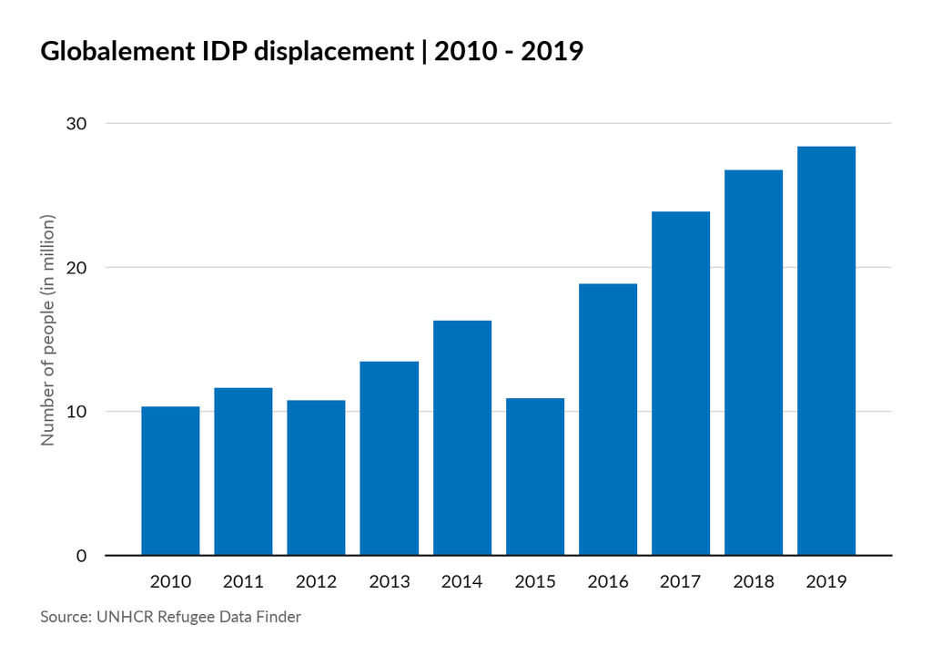

## Tables

Use the `knitr::kable()` function to insert simple already stylized tables. For example:

```r
knitr::kable(head(idp))
```

| year | country | sex | idp |
| --- | --- | --- | --- |
| 2010 | Afghanistan | female | 174608 |
| 2010 | Afghanistan | male | 177299 |
| 2010 | Azerbaijan | female | 302032 |
| 2010 | Azerbaijan | male | 290828 |
| 2010 | Bosnia and Herzegovina | female | 58454 |
| 2010 | Bosnia and Herzegovina | male | 54911 |

Many packages can help you stylize tables, like [`{gt}`](https://gt.rstudio.com/), [`{DT}`](https://rstudio.github.io/DT/) and more. Some of them might be particularly useful for HTML document and, allow you to enable some user intereaction with the table. Below a `{DT}` example that creates a paginated searchable and sortable table:

```r
DT::datatable(idp)
```

|  | year | country | sex | idp |
| --- | --- | --- | --- | --- |
| 1 | 2010 | Afghanistan | female | 174608 |
| 2 | 2010 | Afghanistan | male | 177299 |
| 3 | 2010 | Azerbaijan | female | 302032 |
| 4 | 2010 | Azerbaijan | male | 290828 |
| 5 | 2010 | Bosnia and Herzegovina | female | 58454 |
| 6 | 2010 | Bosnia and Herzegovina | male | 54911 |
| 7 | 2010 | Central African Republic | female | 95640 |
| 8 | 2010 | Central African Republic | male | 96889 |
| 9 | 2010 | Colombia | female | 1816767 |
| 10 | 2010 | Colombia | male | 1855287 |

[output cut: 319 more lines]

## Layout

Quarto supports a variety of page layout options that enable you to author content that:

- Fills the main content region
- Overflows the content region
- Spans the entire page
- Occupies the document margin

We will cover the main fonctionalities here but you can find all the possible options directly on the [Quarto website](https://quarto.org/docs/authoring/article-layout.html).

### Body column

This is the default behaviour and where most of you content will live.

.column-body

If you want to apply different layout simply apply a specific CSS class. For example:

```markdown
:::{.column-body-outset}
Outset content...
:::
```

.column-body-outset

### Page column

If you need more space for your content, you can use the `.column-page` class. Content will extent on the size but nor the cover the whole screen yet.

.column-page

Or a bit narrower with `.column-page-inset` class.

.column-page-inset

### Screen column

For full width content, use the `.column-screen` class. The content will cover the full width of the screen with no margin.

.column-screen

.column-screen-inset

### Margin content

Some content can be placed within the right margin of the document (below the table of content). Like the columns it can be achieve with a css class. Use `.column-margin` to place content on the right side.

.column-margin

All the behaviours mentioned in this section can be applied to images, tables, plots, references and more. Visit the [Quarto page on layouts](https://quarto.org/docs/authoring/article-layout.html) for more information.

## Footnotes

[^1]: Text of the footnote